# Visualization_ggplot

Yaqian Huang

2023-09-03

## Visualization principles

Graphical excellence is the well-designed presentation of interesting data—a matter of substance, of **statistics**, and of **design** … [It] consists of complex ideas communicated with **clarity**, **precision**, and **efficiency**. … [It] is that which gives to the viewer the greatest number of ideas in the shortest time with the least ink in the smallest space … [It] is nearly always multivariate … And graphical excellence requires telling the **truth** about the data. (Tufte, 1983, p. 51).

## Dataset of voicing of glottal consonants (Garellek et al., 2021)

```r
df <- read_csv('df-vis.csv')

df.means <- df %>% group_by(language,Filename,Speaker,label,dur,lartype,syltype,syltypegs,family,area,position)%>%
  select(norm.soe,praat_tier2_duration,percent_voiceless_laryngeal)%>%
  summarise_if(is.numeric, mean, na.rm = T)

head(df)
```

```
## # A tibble: 6 × 56
##   Language Filename Label seg_Start seg_End  t_ms epoch   soe Speaker
##   <chr>    <chr>    <chr>     <dbl>   <dbl> <dbl> <dbl> <dbl> <chr>
## 1 A'ingae  01-floor h          119.    168.   125     1 0.008 A'ingae_NA
## 2 A'ingae  01-floor h          119.    168.   139     1 0.008 A'ingae_NA
## 3 A'ingae  01-floor h          119.    168.   151     1 0.007 A'ingae_NA
## 4 A'ingae  01-floor h          119.    168.   163     1 0.02  A'ingae_NA
## 5 A'ingae  01-floor h          292.    333.   292     1 0.006 A'ingae_NA
## 6 A'ingae  01-floor h          292.    333.   300     1 0.002 A'ingae_NA
## # ℹ 47 more variables: `Laryngeal type` <chr>, Word <chr>,
## #   `Preceding sound` <chr>, `Target sound` <chr>, `Following sound` <chr>,
## #   `Nasal V` <chr>, `Tone on target` <chr>, `Stress on target` <chr>,
## #   `Word position` <chr>, `Phrase position` <chr>, Gloss <chr>, Genus <chr>,
## #   Family <chr>, `Macro area` <chr>, SylTypeGs <chr>, SylType <chr>,
## #   sound_label <chr>, laryngeal_label <chr>, praat_tier1_duration <dbl>,
## #   praat_tier2_duration <dbl>, percent_laryngeal <dbl>, …
```

```r
head(df.means)
```

```
## # A tibble: 6 × 14
## # Groups:   language, Filename, Speaker, label, dur, lartype, syltype,
## #   syltypegs, family, area [6]
##   language Filename   Speaker label   dur lartype syltype syltypegs family area
##   <chr>    <chr>      <chr>   <chr> <dbl> <chr>   <chr>   <chr>     <chr>  <chr>
## 1 A'ingae  01-floor   A'inga… h      41.0 Th      VThV    VThV      A'ing… Sout…
## 2 A'ingae  01-floor   A'inga… h      49.1 Th      ThV     ThV       A'ing… Sout…
## 3 A'ingae  01-floor   A'inga… h      69.2 Th      VThV    VThV      A'ing… Sout…
## 4 A'ingae  04-to_sea… A'inga… h      58.1 Th      ThV     ThV       A'ing… Sout…
## 5 A'ingae  04-to_sea… A'inga… h      60.9 Th      VThV    VThV      A'ing… Sout…
## 6 A'ingae  05-becomi… A'inga… gs    233.  gs      VgsV    VgsV      A'ing… Sout…
## # ℹ 4 more variables: position <chr>, norm.soe <dbl>,
## #   praat_tier2_duration <dbl>, percent_voiceless_laryngeal <dbl>
```

## set plot style

```r
style <- list(
        theme_bw(base_size = 14),
        theme(
                aspect.ratio     = .8,
                legend.position  = "none",
                strip.background = element_blank(),
                strip.text       = element_text(color = "black", hjust = 0, size = 11),
                panel.border     = element_rect(color = "black", fill = NA),
                axis.text.x = element_text(angle=45, hjust=1)
        )
)

style2 <- list(
        theme_bw(base_size = 14),
        theme(
                aspect.ratio     = .8,
                strip.background = element_blank(),
                strip.text       = element_text(color = "black", hjust = 0, size = 11),
                panel.border     = element_rect(color = "black", fill = NA),
        )
)
```

## Categorical ~ 0

### What is the distribution of area of languages in the dataset? language family?

```r
# barplot of counts
# highlight sample size when n is small

df %>% count(area)
```

```
## # A tibble: 7 × 2
##   area              n
##   <chr>         <int>
## 1 Africa         3412
## 2 Australia       464
## 3 Eurasia       10306
## 4 North America  4010
## 5 Papunesia      5436
## 6 South America  1538
## 7 <NA>           1531
```

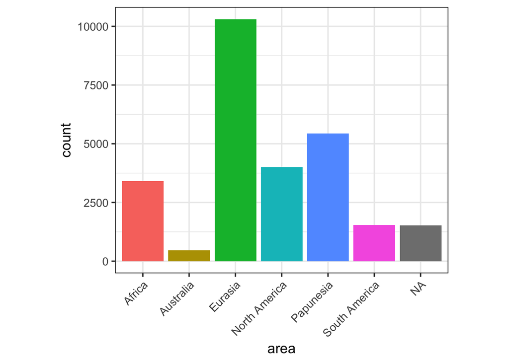

```r
ggplot(df, aes(x=area, fill=area)) +
  geom_bar()+style
```

```r
# plot only top 10 language family (with NA)
df %>% count(family) %>% arrange(desc(n)) %>% head(11)
```

```
## # A tibble: 11 × 2
##    family               n
##    <chr>            <int>
##  1 Indo-European     5911
##  2 Austronesian      5306
##  3 Sino-Tibetan      2664
##  4 Oto-Manguean      2040
##  5 <NA>              1531
##  6 Niger-Congo       1355
##  7 Afro-Asiatic      1187
##  8 Mon-Khmer         1124
##  9 East Sudanic       751
## 10 Kawapanan          545
## 11 Plateau Penutian   494
```

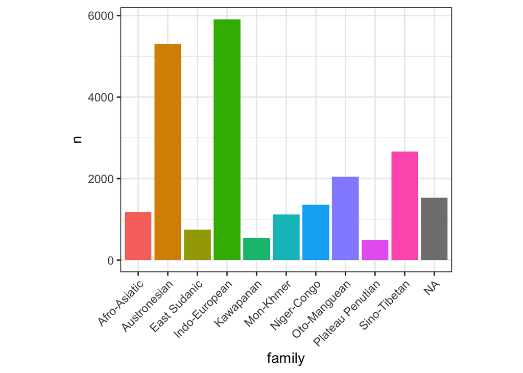

```r
df %>% count(family) %>% arrange(desc(n)) %>% head(11) %>%
  ggplot(aes(x=family, y=n, fill = family))+
  geom_bar(stat='identity')+style
```

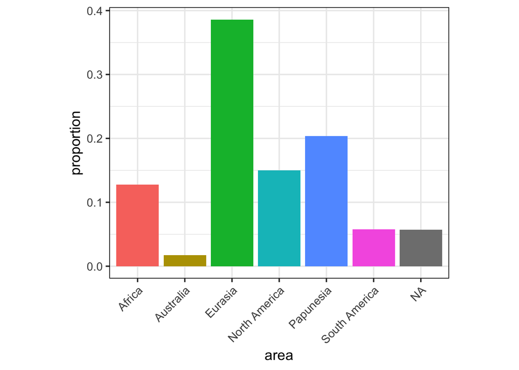

```r
# proportion
# easier interpretation

df %>% group_by(area)%>%
  summarize(n = n())%>%
  mutate(proportion=prop.table(n))%>%
  ggplot(aes(x=area, y=proportion, fill=area)) +
  geom_bar(stat = 'identity')+style
```

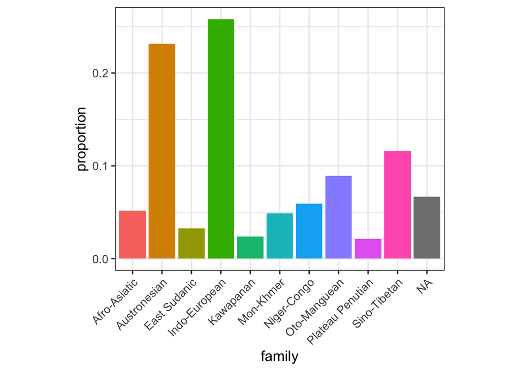

```r
df %>% count(family) %>% arrange(desc(n)) %>% head(11) %>%
  mutate(proportion=prop.table(n)) %>%
  ggplot(aes(x=family, y=proportion, fill = family))+
  geom_bar(stat='identity')+style
```

## Numerical ~ 0

### What is the distribution of normalized soe (voicing intensity measure)?

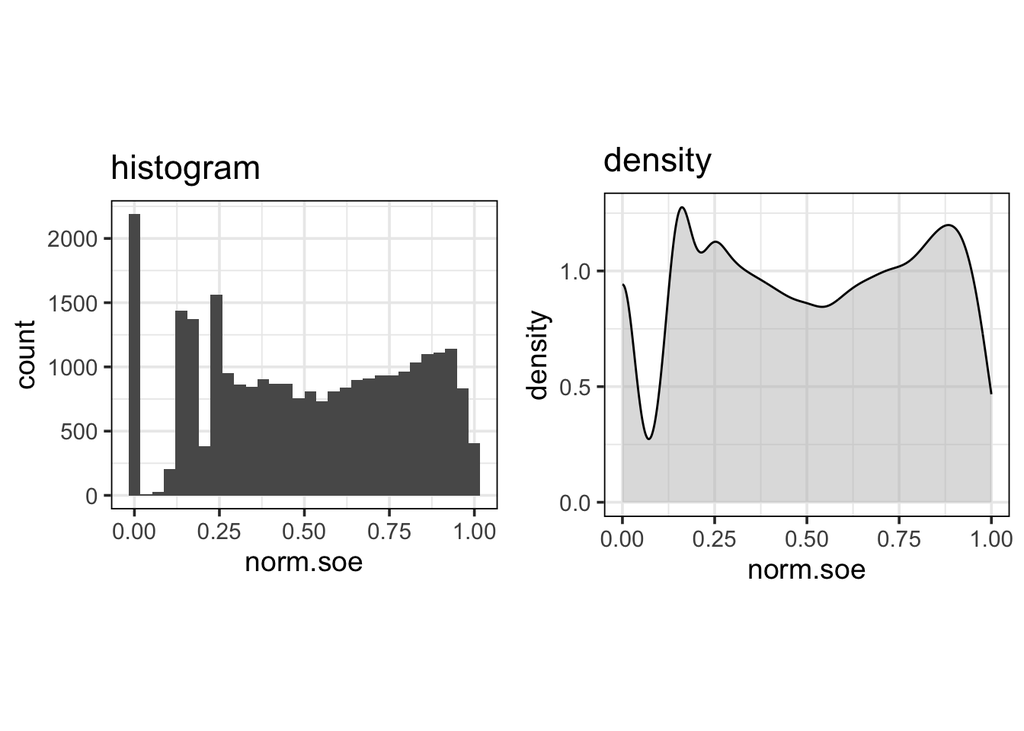

```r
# histogram
den <- ggplot(df, aes(x=norm.soe))+
  geom_histogram()+
    ggtitle('histogram')+style2

# smoothed density
smo <- ggplot(df, aes(x=norm.soe))+
  geom_density(fill='gray', alpha=0.5)+
    ggtitle('density')+style2

gridExtra::grid.arrange(den, smo, nrow=1)
```

## Numerical ~ Numerical

### What is the relationship between norm.soe and percentage of voicing?

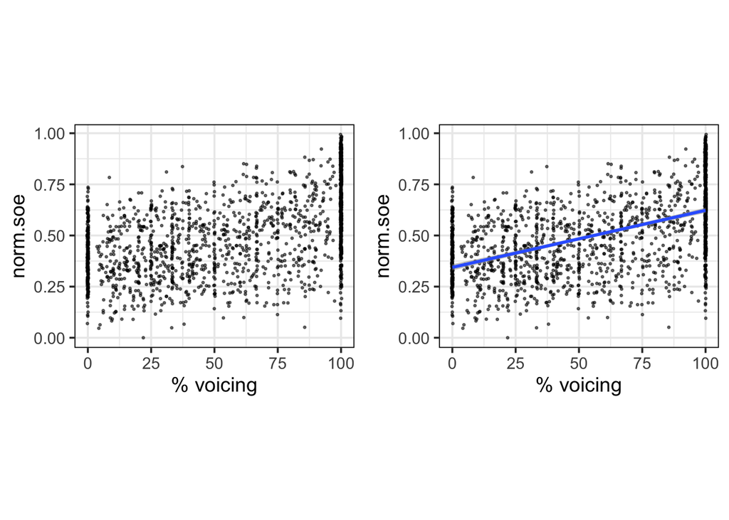

```r
# scatterplot
sca <- ggplot(df.means,aes(x=100-percent_voiceless_laryngeal, y=norm.soe, alpha=0.5)) +
  geom_point(size=0.5, position=position_jitter(0.25))+
  scale_x_continuous('% voicing')+
  style2+theme(legend.position = 'none')

# scatterplot + fitted lm through smooth
scalm <- ggplot(df.means,aes(x=100-percent_voiceless_laryngeal, y=norm.soe, alpha=0.5)) +
  geom_point(size=0.5, position=position_jitter(0.25))+
  geom_smooth(method = 'lm',na.rm = T)+
  scale_x_continuous('% voicing')+
  style2+theme(legend.position = 'none')


gridExtra::grid.arrange(sca, scalm, nrow=1)
```

## Numerical ~ Categorical

### How does mean norm.soe vary across voiceless and voiced glottal fricatives and breathy vowels?

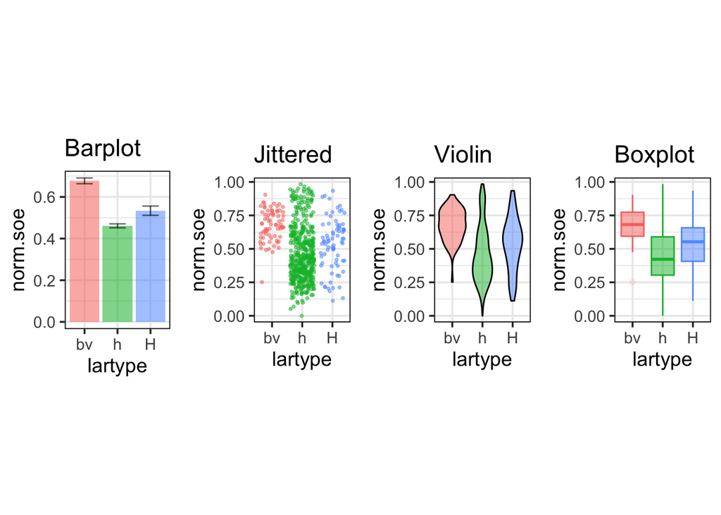

```r
# boxplot
box <- ggplot(df.means%>%filter(syltype %in% c("hV","HV","VhV","VHV","Vh","VH","Cbv","CbvC")), aes(x=lartype, color=lartype, fill=lartype, y=norm.soe))+
  geom_boxplot(alpha=0.5, outlier.alpha = 0.1)+
  ggtitle('Boxplot')+
  style2+theme(legend.position = 'none',aspect.ratio = 1.5)


# violin; large n
vio <- ggplot(df.means%>%filter(syltype %in% c("hV","HV","VhV","VHV","Vh","VH","Cbv","CbvC")), aes(x=lartype, color=lartype, fill=lartype, y=norm.soe))+
  geom_violin(alpha=.5,color='black')+
  ggtitle('Violin')+
  style2+theme(legend.position = 'none',aspect.ratio = 1.5)

# jitter; small n; show all data points
jit <- ggplot(df.means%>%filter(syltype %in% c("hV","HV","VhV","VHV","Vh","VH","Cbv","CbvC")), aes(x=lartype, color=lartype, fill=lartype, y=norm.soe))+
  geom_jitter(size=0.7, alpha=0.5)+
  ggtitle('Jittered')+
  style2+theme(legend.position = 'none',aspect.ratio = 1.5)

# bar plot + error bar
bar <- ggplot(df.means%>%filter(syltype %in% c("hV","HV","VhV","VHV","Vh","VH","Cbv","CbvC")), aes(x=lartype, fill=lartype, y=norm.soe,alpha=0.5))+
  stat_summary(fun.y = mean,
               geom="bar")+
  stat_summary(fun.data = mean_se,
               geom="errorbar",
               width=0.5)+
  ggtitle('Barplot')+
  style2+theme(legend.position = 'none',aspect.ratio = 1.5)

gridExtra::grid.arrange(bar, jit, vio, box, nrow=1)
```

## Numerical ~ Numerical + Categorical

### How does norm.soe vary over the time course and across voiceless and voiced glottal fricatives and breathy vowels?

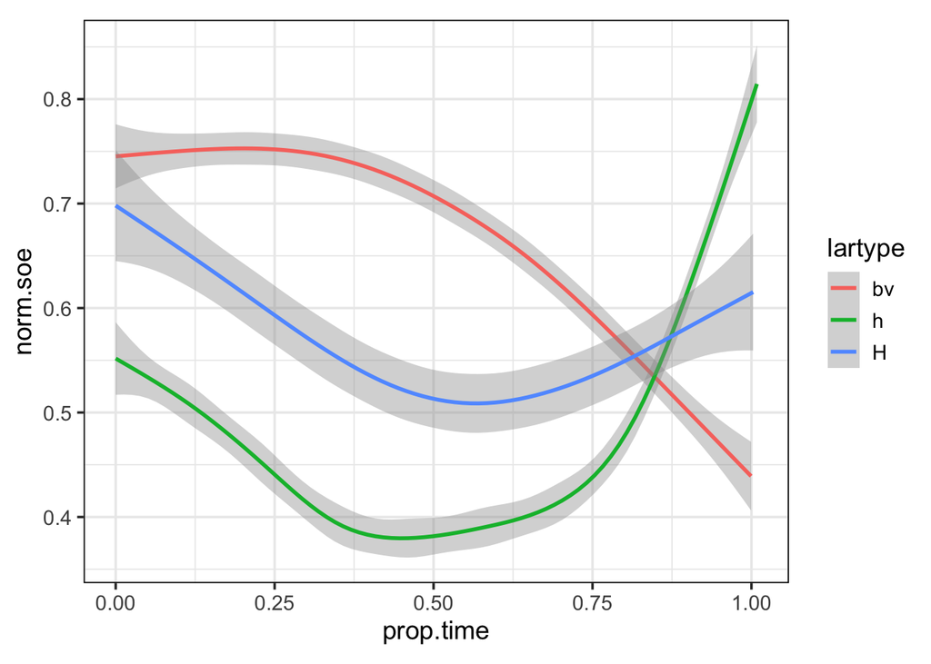

```r
# splines
# color coded
df %>% filter(syltype %in% c("hV","HV","VhV","VHV","Vh","VH","Cbv","CbvC"))%>%
        ggplot(aes(prop.time, norm.soe, color = lartype))+
        geom_smooth() + style2
```

## Numerical ~ Categorical + Categorical

### How does mean norm.soe vary across voiceless and voiced glottal fricatives and breathy vowels, and word positions?

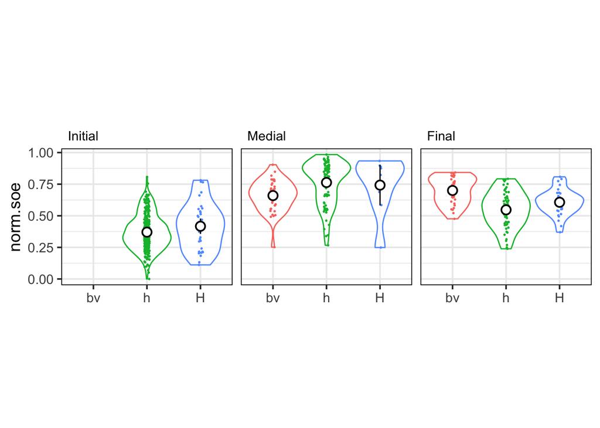

```r
mean_ci <- function(x){
  m = mean(x,na.rm=T)
  se = sd(x,na.rm=T)/sqrt(length(x))
  ql = qnorm(1-0.025)
  c('y'=m, 'ymin'=m-ql*se, 'ymax'=m+ql*se)
}

# violin + jitter + pointrange

df.means %>% filter(syltype %in% c("hV","HV","VhV","VHV","Vh","VH","Cbv","CbvC"))%>%
  mutate(position = factor(position,levels=c('Initial','Medial','Final')))%>%
ggplot(aes(x=lartype,y=norm.soe ,color=lartype))+
  geom_violin(alpha=0.7,na.rm = T,scale = "width")+
  geom_jitter(height=0,width=0.05,size=.3,aes(color=lartype,fill=lartype))+
  stat_summary(fun.data = mean_ci,
               geom="pointrange",
               fatten = 1.5,
               position=position_dodge(width=0.9),
               size=2,shape=21,
               color="black",
               fill="white")+
  facet_wrap(~position)+
  style2+theme(legend.position = "none",axis.title.x = element_blank()
  )
```

## Numerical ~ Numerical + 2*Categorial

### How does norm.soe vary over the time course and across voiceless and voiced glottal fricatives and breathy vowels, and word positions?

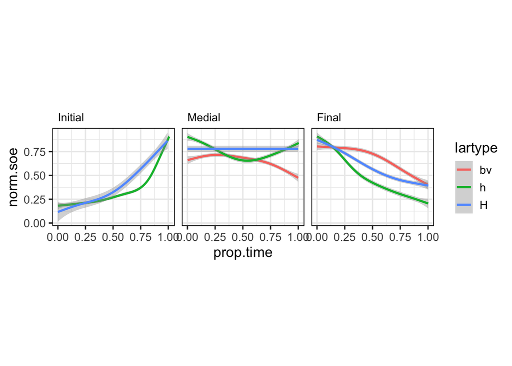

```r
df %>% filter(syltype %in% c("hV","HV","VhV","VHV","Vh","VH","Cbv","CbvC"))%>%
  mutate(position = factor(position,levels=c('Initial','Medial','Final')))%>%
        ggplot(aes(prop.time, norm.soe, color = lartype)) +
        geom_smooth() +
        facet_wrap(~ position, scales = "free_x") + style2
```